# Data Audit Report

## Definition Summary

Overview of the variables expected to be in this data file.

| name | type | description |
| --- | --- | --- |
| cohortPatientId | id | De-identified patient identification code |
| birthSex | enum | Sex at birth |
| presentSex | enum | Present sex |
| birthYear | year | Year of patient’s birth |
| race | enum | Patient’s race |
| hispanic | boolean | Patient’s Hispanic ethnicity status |
| enrollDate | date | Date the patient enrolled in your cohort (PT0) |
| lastActivityDate | date | The date of the last recorded patient activity |
| deathDate | date | Patient’s death date |
| deathDateSource | string | Source of patient’s death date information |
| subSiteID | string | NA |
| hivNegative | enum | NA |
| BirthCountry | string | NA |
| transgendered | boolean | NA |
| LastNDIDate | date | NA |

## Data File Summary

### File Overview

Properties of the uploaded data file.

[output not shown]

### Column Overview

The below table shows the following statistics for each column:

- **Missing (N)**: Number of missing values
- **%**: Percentage of rows with missing values
- **Unique Values**: Number of distinct values
- **Cardinality**: Percentage of values that are unique
  - High (>90%): Most values are unique (e.g., IDs)
  - Medium (1-90%): Some repetition (e.g., dates)
  - Low (<1%): Many repeated values (e.g., categories)

| Variable | Type | Missing.N | Missing.Pct | Unique | Cardinality |
| --- | --- | --- | --- | --- | --- |
| presentSex | enum | 0 | 0.0 | 2 | Low (0.0%) |
| birthYear | year | 0 | 0.0 | 61 | Low (0.1%) |
| cohortPatientId | id | 0 | 0.0 | 54923 | High (100.0%) |
| deathDate | date | 0 | 0.0 | 9105 | Medium (16.6%) |
| lastActivityDate | date | 0 | 0.0 | 9115 | Medium (16.6%) |
| race | enum | 0 | 0.0 | 7 | Low (0.0%) |
| hispanic | boolean | 0 | 0.0 | 2 | Low (0.0%) |
| enrollDate | date | 0 | 0.0 | 8754 | Medium (15.9%) |
| transgendered | boolean | 0 | 0.0 | 2 | Low (0.0%) |

## Variables

Variable:

### cohortPatientId

The following table shows the basic characteristics of this variable in the submitted data. Definitions of these metrics can be found above under Column Overview.

| Metric | Value |
| --- | --- |
| Type | id |
| Missing (N) | 0 |
| Missing (%) | 0.0 |
| Unique | 54923 |
| Cardinality | High (100.0%) |

#### Validation Results

Results of automated checks to verify the data meets the requirements specified in the NA-Accord data model.

| Validator | Status | Message |
| --- | --- | --- |
| id | ✅ Success | All values in column ‘cohortPatientId’ are valid IDs |
| no_duplicates | ✅ Success | All values in column ‘cohortPatientId’ are unique |

#### Data Summary

##### Basic Stats

Overview of the variable’s basic characteristics including counts and uniqueness.

| Metric | Value |
| --- | --- |
| Count | 54,923 |
| Unique | 54,923 |
| Empty | 0 (0.0%) |

##### Examples

The most common values found in the data.

| Value | Count | Percentage |
| --- | --- | --- |
| 3 | 1 | 0.0% |
| 29 | 1 | 0.0% |
| 40 | 1 | 0.0% |
| 61 | 1 | 0.0% |
| 64 | 1 | 0.0% |
| 72 | 1 | 0.0% |
| 89 | 1 | 0.0% |
| 102 | 1 | 0.0% |
| 104 | 1 | 0.0% |
| 118 | 1 | 0.0% |

Variable:

### birthSex

This variable is defined in the table definition but cannot be found in the submitted data.

Variable:

### presentSex

The following table shows the basic characteristics of this variable in the submitted data. Definitions of these metrics can be found above under Column Overview.

| Metric | Value |
| --- | --- |
| Type | enum |
| Missing (N) | 0 |
| Missing (%) | 0.0 |
| Unique | 2 |
| Cardinality | Low (0.0%) |

#### Validation Results

Results of automated checks to verify the data meets the requirements specified in the NA-Accord data model.

| Validator | Status | Message |
| --- | --- | --- |
| enum_allowed_values | ❌ Error | Column ‘presentSex’ contains 2 values outside allowed set: [‘Female’, ‘Male’, ‘Intersexed’] M: Showing first 973 affected rows Rows: 1, 2, 3, 4, 5, 7, 8, 9, 10, 11, 12, 13, 14, 15, 16, 17, 18, 19, 20,… |
| required_when | ✅ Success | Column ‘presentSex’ meets all conditional requirements |
| forbidden_when | ✅ Success | Column ‘presentSex’ meets all conditional restrictions |

#### Data Summary

##### Barchart

Visual representation of the most frequent values.

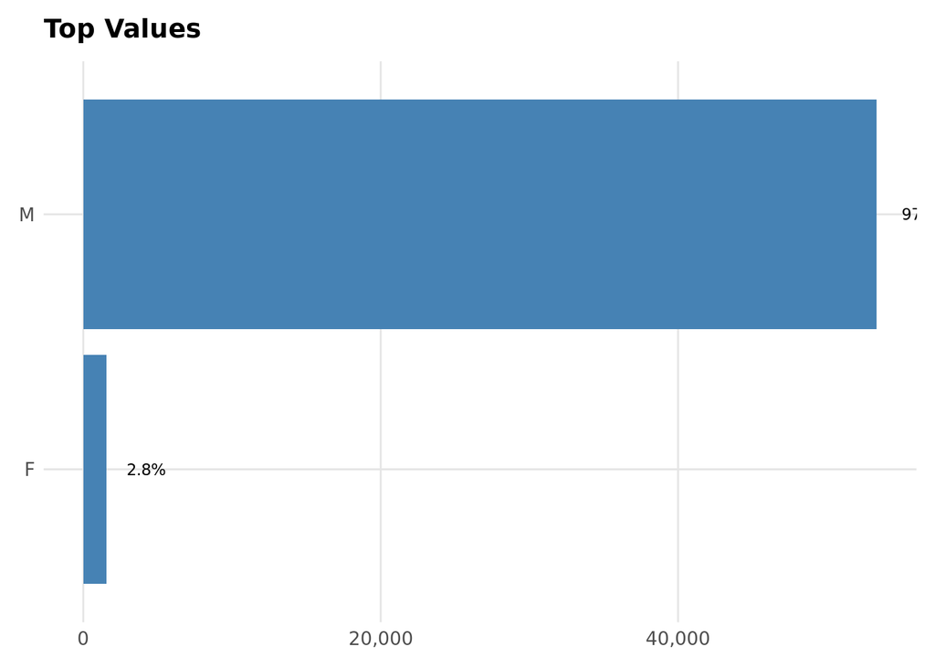

##### Basic Stats

Overview of the variable’s basic characteristics including counts and uniqueness.

| Metric | Value |
| --- | --- |
| Count | 54,923 |
| Unique | 2 |
| Empty | 0 (0.0%) |

##### Examples

The most common values found in the data.

| Value | Count | Percentage |
| --- | --- | --- |
| M | 53,366 | 97.2% |
| F | 1,557 | 2.8% |

Variable:

### birthYear

The following table shows the basic characteristics of this variable in the submitted data. Definitions of these metrics can be found above under Column Overview.

| Metric | Value |
| --- | --- |
| Type | year |
| Missing (N) | 0 |
| Missing (%) | 0.0 |
| Unique | 61 |
| Cardinality | Low (0.1%) |

#### Validation Results

Results of automated checks to verify the data meets the requirements specified in the NA-Accord data model.

| Validator | Status | Message |
| --- | --- | --- |
| year | ✅ Success | All non-empty values in column ‘birthYear’ are valid years between 1000 and 2035 |
| range | ✅ Success | All non-empty values in column ‘birthYear’ are within range [1900 - 2025] |
| required | ✅ Success | All values in required column ‘birthYear’ are present |

#### Data Summary

##### Basic Stats

Overview of the variable’s basic characteristics including counts and uniqueness.

| Metric | Value |
| --- | --- |
| Count | 54,923 |
| Unique | 61 |
| Empty | 0 (0.0%) |

##### Histogram

Distribution of numeric values.

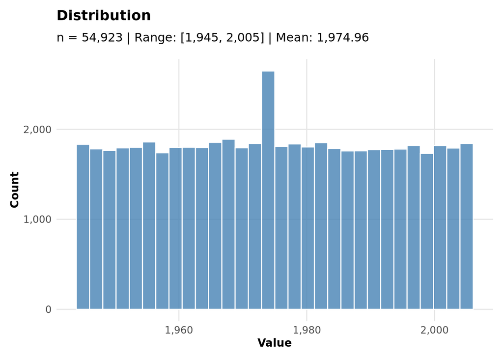

Variable:

### race

The following table shows the basic characteristics of this variable in the submitted data. Definitions of these metrics can be found above under Column Overview.

| Metric | Value |
| --- | --- |
| Type | enum |
| Missing (N) | 0 |
| Missing (%) | 0.0 |
| Unique | 7 |
| Cardinality | Low (0.0%) |

#### Validation Results

Results of automated checks to verify the data meets the requirements specified in the NA-Accord data model.

| Validator | Status | Message |
| --- | --- | --- |
| enum_allowed_values | ✅ Success | All values in column ‘race’ are within allowed set |
| required | ✅ Success | All values in required column ‘race’ are present |

#### Data Summary

##### Barchart

Visual representation of the most frequent values.

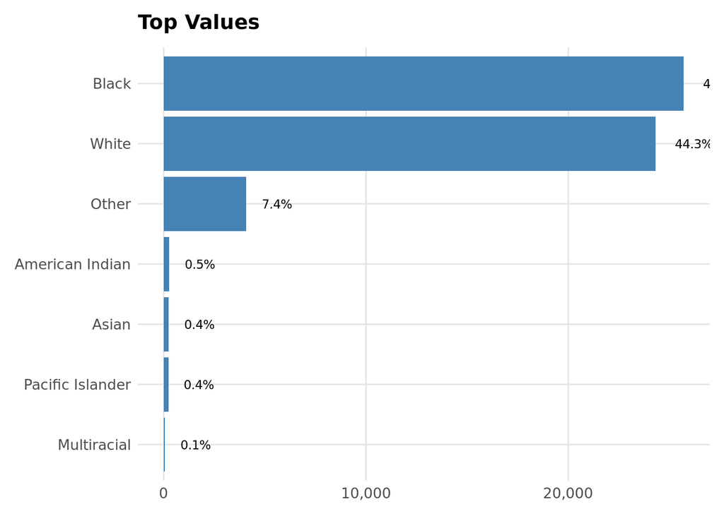

##### Basic Stats

Overview of the variable’s basic characteristics including counts and uniqueness.

| Metric | Value |
| --- | --- |
| Count | 54,923 |
| Unique | 7 |
| Empty | 0 (0.0%) |

##### Examples

The most common values found in the data.

| Value | Count | Percentage |
| --- | --- | --- |
| Black | 25,705 | 46.8% |
| White | 24,324 | 44.3% |
| Other | 4,081 | 7.4% |
| American Indian | 273 | 0.5% |
| Asian | 246 | 0.4% |
| Pacific Islander | 236 | 0.4% |
| Multiracial | 58 | 0.1% |

Variable:

### hispanic

The following table shows the basic characteristics of this variable in the submitted data. Definitions of these metrics can be found above under Column Overview.

| Metric | Value |
| --- | --- |
| Type | boolean |
| Missing (N) | 0 |
| Missing (%) | 0.0 |
| Unique | 2 |
| Cardinality | Low (0.0%) |

#### Validation Results

Results of automated checks to verify the data meets the requirements specified in the NA-Accord data model.

| Validator | Status | Message |
| --- | --- | --- |
| boolean | ✅ Success | All non-empty values in column ‘hispanic’ are valid boolean values |
| boolean_allowed_values | ✅ Success | All values in column ‘hispanic’ are within allowed boolean representations |
| required | ✅ Success | All values in required column ‘hispanic’ are present |

#### Data Summary

##### Barchart

Visual representation of the most frequent values.

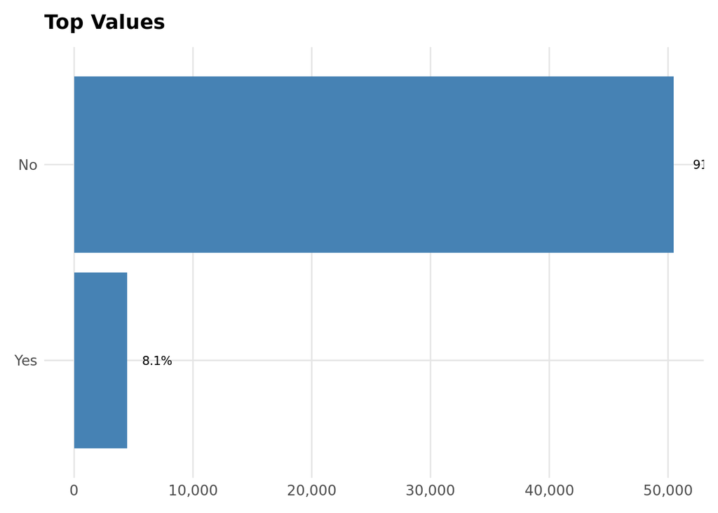

##### Basic Stats

Overview of the variable’s basic characteristics including counts and uniqueness.

| Metric | Value |
| --- | --- |
| Count | 54,923 |
| Unique | 2 |
| Empty | 0 (0.0%) |

##### Examples

The most common values found in the data.

| Value | Count | Percentage |
| --- | --- | --- |
| No | 50,484 | 91.9% |
| Yes | 4,439 | 8.1% |

Variable:

### enrollDate

The following table shows the basic characteristics of this variable in the submitted data. Definitions of these metrics can be found above under Column Overview.

| Metric | Value |
| --- | --- |
| Type | date |
| Missing (N) | 0 |
| Missing (%) | 0.0 |
| Unique | 8754 |
| Cardinality | Medium (15.9%) |

#### Validation Results

Results of automated checks to verify the data meets the requirements specified in the NA-Accord data model.

| Validator | Status | Message |
| --- | --- | --- |
| date | ✅ Success | All non-empty values in column ‘enrollDate’ are valid dates |
| required | ✅ Success | All values in required column ‘enrollDate’ are present |

#### Data Summary

##### Basic Stats

Overview of the variable’s basic characteristics including counts and uniqueness.

| Metric | Value |
| --- | --- |
| Count | 54,923 |
| Unique | 8,754 |
| Empty | 0 (0.0%) |

##### Date

Analysis of date ranges and distribution in the data.

[output not shown]

**Date Distribution:**

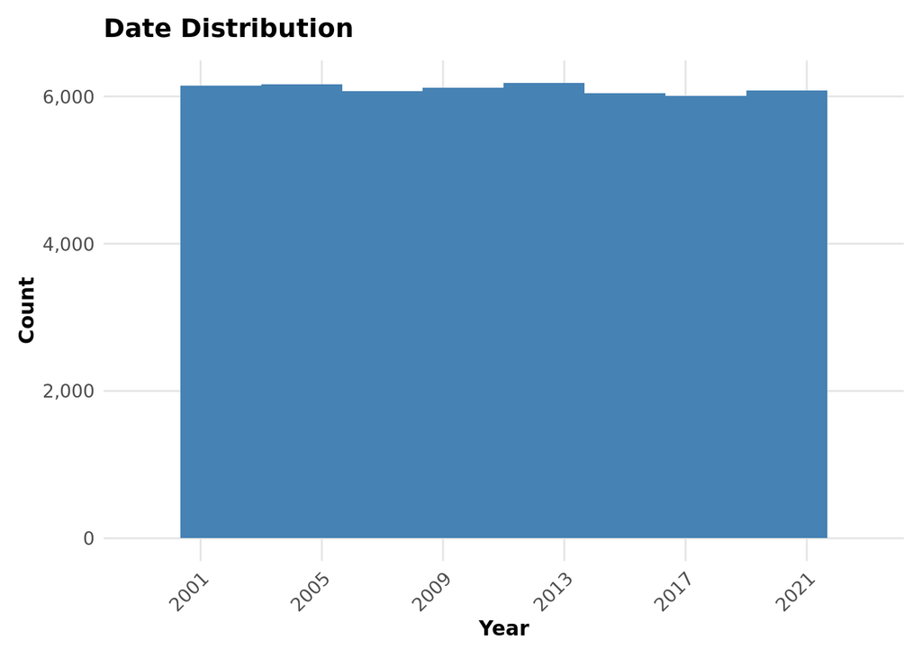

Variable:

### lastActivityDate

The following table shows the basic characteristics of this variable in the submitted data. Definitions of these metrics can be found above under Column Overview.

| Metric | Value |
| --- | --- |
| Type | date |
| Missing (N) | 0 |
| Missing (%) | 0.0 |
| Unique | 9115 |
| Cardinality | Medium (16.6%) |

#### Validation Results

Results of automated checks to verify the data meets the requirements specified in the NA-Accord data model.

| Validator | Status | Message |
| --- | --- | --- |
| date | ✅ Success | All non-empty values in column ‘lastActivityDate’ are valid dates |
| required | ✅ Success | All values in required column ‘lastActivityDate’ are present |

#### Data Summary

##### Basic Stats

Overview of the variable’s basic characteristics including counts and uniqueness.

| Metric | Value |
| --- | --- |
| Count | 54,923 |
| Unique | 9,115 |
| Empty | 0 (0.0%) |

##### Date

Analysis of date ranges and distribution in the data.

[output not shown]

**Date Distribution:**

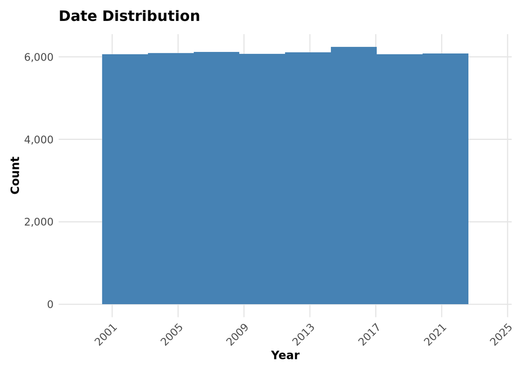

Variable:

### deathDate

The following table shows the basic characteristics of this variable in the submitted data. Definitions of these metrics can be found above under Column Overview.

| Metric | Value |
| --- | --- |
| Type | date |
| Missing (N) | 0 |
| Missing (%) | 0.0 |
| Unique | 9105 |
| Cardinality | Medium (16.6%) |

#### Validation Results

Results of automated checks to verify the data meets the requirements specified in the NA-Accord data model.

| Validator | Status | Message |
| --- | --- | --- |
| date | ✅ Success | All non-empty values in column ‘deathDate’ are valid dates |

#### Data Summary

##### Basic Stats

Overview of the variable’s basic characteristics including counts and uniqueness.

| Metric | Value |
| --- | --- |
| Count | 54,923 |
| Unique | 9,105 |
| Empty | 0 (0.0%) |

##### Date

Analysis of date ranges and distribution in the data.

[output not shown]

**Date Distribution:**

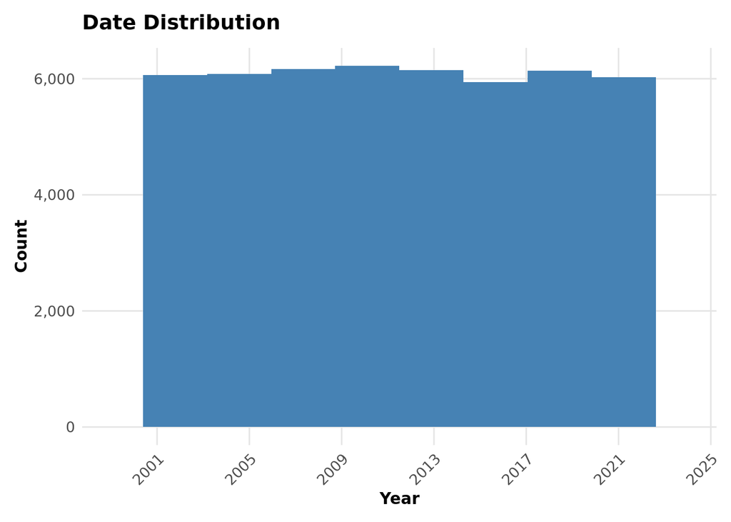

Variable:

### deathDateSource

This variable is defined in the table definition but cannot be found in the submitted data.

Variable:

### subSiteID

This variable is defined in the table definition but cannot be found in the submitted data.

Variable:

### hivNegative

This variable is defined in the table definition but cannot be found in the submitted data.

Variable:

### BirthCountry

This variable is defined in the table definition but cannot be found in the submitted data.

Variable:

### transgendered

The following table shows the basic characteristics of this variable in the submitted data. Definitions of these metrics can be found above under Column Overview.

| Metric | Value |
| --- | --- |
| Type | boolean |
| Missing (N) | 0 |
| Missing (%) | 0.0 |
| Unique | 2 |
| Cardinality | Low (0.0%) |

#### Validation Results

Results of automated checks to verify the data meets the requirements specified in the NA-Accord data model.

| Validator | Status | Message |
| --- | --- | --- |
| boolean | ❌ Error | Column ‘transgendered’ contains 54708 non-boolean values NA: Showing first 1000 affected rows Rows: 1, 2, 3, 4, 5, 6, 7, 8, 9, 10, 11, 12, 13, 14, 15, 16, 17, 18, 19, 20, 21, 22, 23, 24, 25, 26, 27, 2… |
| boolean_allowed_values | ❌ Error | Column ‘transgendered’ contains 1 values outside allowed set: { True: [‘Yes’], False: [‘No’] } NA: Showing first 1000 affected rows Rows: 1, 2, 3, 4, 5, 6, 7, 8, 9, 10, 11, 12, 13, 14, 15, 16, 17, 18,… |
| required | ✅ Success | All values in required column ‘transgendered’ are present |

#### Data Summary

##### Barchart

Visual representation of the most frequent values.

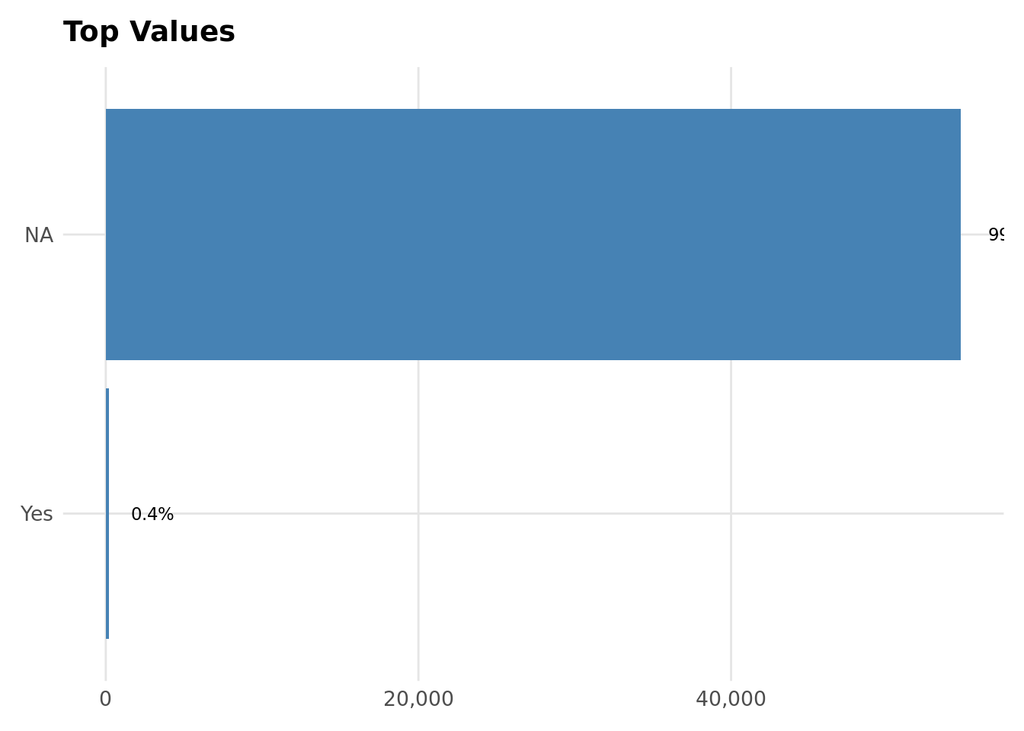

##### Basic Stats

Overview of the variable’s basic characteristics including counts and uniqueness.

| Metric | Value |
| --- | --- |
| Count | 54,923 |
| Unique | 2 |
| Empty | 0 (0.0%) |

##### Examples

The most common values found in the data.

| Value | Count | Percentage |
| --- | --- | --- |
| NA | 54,708 | 99.6% |
| Yes | 215 | 0.4% |

Variable:

### LastNDIDate

This variable is defined in the table definition but cannot be found in the submitted data.